# Practical machine learning project

## Preparation

In order to conduct this exercise we need to choose the working directory and select some packages to use. In order the results to be reproduced we also set a seed.

```r
rm (list = ls ())
setwd("~/Work/Cursos/Coursera Applied Machine learning/Proyecto")
library(caret)
library(AppliedPredictiveModeling)
library(rattle)
library(rpart)
library(randomForest)
set.seed(1000)
```

## Data obtention

We automatically download the training data

```r
fileURL1<-"https://d396qusza40orc.cloudfront.net/predmachlearn/pml-training.csv"
if(!file.exists("pml-training.csv"))
{
  download.file(fileURL1,destfile="pml-training.csv",method="curl")
  dateDownloaded_Training <- date()
}
```

and the testing data

```r
fileURL2<-"https://d396qusza40orc.cloudfront.net/predmachlearn/pml-testing.csv"
if(!file.exists("pml-testing.csv"))
{
  download.file(fileURL2,destfile="pml-training.csv",method="curl")
  dateDownloaded_Testing <- date()
}
```

We read the data. They contain missing values. We make sure we read them correctly

```r
training <- read.csv("pml-training.csv", na.strings=c("NA","#DIV/0!",""))
testing <- read.csv("pml-testing.csv", na.strings=c("NA","#DIV/0!",""))
```

```r
trainIndex <- createDataPartition(y= training$classe, p=0.6, list=FALSE)
subset_training <- training[trainIndex,]
subset_testing <- training[-trainIndex,]
```

## Cleaning data

Missing values: We remove those numeric variables with many missing values. Those variables that have more than 60% of the data missing are removed

```r
a <-sapply(subset_training, function(x) sum(is.na(x))>round(0.6*dim(subset_training)[1]))
clean_training <- training[a==FALSE]
```

We check if there are still missing values to handle

```r
sum(is.na(clean_training))
```

```
## [1] 0
```

We could eliminate summary variables like those starting by std but this have already been eliminated in the previous step because they had many missing values.

We eliminate variables that do not provide valuable information:

```r
clean_training <- clean_training[ , -which(names(clean_training) %in% c("num_window","X","user_name","raw_timestamp_part_1","raw_timestamp_part_2","cvtd_timestamp", "new_window"))]
```

## Training ML models

We train a decision tree:

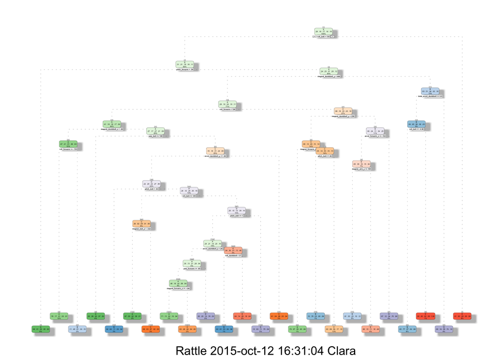

```r
modFitDT <- rpart(classe ~ ., data=clean_training, method="class")
fancyRpartPlot(modFitDT)
```

Now we make the same transformations performed in the training set in the testing datasets

```r
index1 <- colnames(clean_training)
index2 <- colnames(clean_training[, -53]) #already with classe column removed
clean_subset_testing <- subset_testing[,index1]
testing <- testing[index2]
```

We make predictions with the testing data sets

```r
prediction2 <- predict(modFitDT, clean_subset_testing, type = "class")
```

And obtain the confusion Matrix

```r
confusionMatrix(prediction2, clean_subset_testing$classe)
```

```
## Confusion Matrix and Statistics
##
##           Reference
## Prediction    A    B    C    D    E
##          A 1985  217   18   80   27
##          B   81  966  115  116  119
##          C   52  144 1111  212  164
##          D   72  112   82  778   79
##          E   42   79   42  100 1053
##
## Overall Statistics
##
##                Accuracy : 0.7511
##                  95% CI : (0.7414, 0.7606)
##     No Information Rate : 0.2845
##     P-Value [Acc > NIR] : < 2.2e-16
##
##                   Kappa : 0.6847
##  Mcnemar's Test P-Value : < 2.2e-16
##
## Statistics by Class:
##
##                      Class: A Class: B Class: C Class: D Class: E
## Sensitivity            0.8893   0.6364   0.8121  0.60498   0.7302
## Specificity            0.9391   0.9319   0.9117  0.94741   0.9589
## Pos Pred Value         0.8530   0.6915   0.6601  0.69279   0.8002
## Neg Pred Value         0.9552   0.9144   0.9583  0.92444   0.9404
## Prevalence             0.2845   0.1935   0.1744  0.16391   0.1838
## Detection Rate         0.2530   0.1231   0.1416  0.09916   0.1342
## Detection Prevalence   0.2966   0.1781   0.2145  0.14313   0.1677
## Balanced Accuracy      0.9142   0.7841   0.8619  0.77619   0.8446
```

We observe that the accuracy is 0.75 in the testing subset. We train a random forest and see if we improve this result:

```r
modFitRF <- randomForest(classe ~. , data=clean_training)
prediction4 <- predict(modFitRF, clean_training, type = "class")
confusionMatrix(prediction4, clean_training$classe)
```

```
## Confusion Matrix and Statistics
##
##           Reference
## Prediction    A    B    C    D    E
##          A 5580    0    0    0    0
##          B    0 3797    0    0    0
##          C    0    0 3422    0    0
##          D    0    0    0 3216    0
##          E    0    0    0    0 3607
##
## Overall Statistics
##
##                Accuracy : 1
##                  95% CI : (0.9998, 1)
##     No Information Rate : 0.2844
##     P-Value [Acc > NIR] : < 2.2e-16
##
##                   Kappa : 1
##  Mcnemar's Test P-Value : NA
##
## Statistics by Class:
##
##                      Class: A Class: B Class: C Class: D Class: E
## Sensitivity            1.0000   1.0000   1.0000   1.0000   1.0000
## Specificity            1.0000   1.0000   1.0000   1.0000   1.0000
## Pos Pred Value         1.0000   1.0000   1.0000   1.0000   1.0000
## Neg Pred Value         1.0000   1.0000   1.0000   1.0000   1.0000
## Prevalence             0.2844   0.1935   0.1744   0.1639   0.1838
## Detection Rate         0.2844   0.1935   0.1744   0.1639   0.1838
## Detection Prevalence   0.2844   0.1935   0.1744   0.1639   0.1838
## Balanced Accuracy      1.0000   1.0000   1.0000   1.0000   1.0000
```

We test it in the testing subset

```r
prediction5 <- predict(modFitRF, clean_subset_testing, type = "class")
confusionMatrix(prediction5, clean_subset_testing$classe)
```

```
## Confusion Matrix and Statistics
##
##           Reference
## Prediction    A    B    C    D    E
##          A 2232    0    0    0    0
##          B    0 1518    0    0    0
##          C    0    0 1368    0    0
##          D    0    0    0 1286    0
##          E    0    0    0    0 1442
##
## Overall Statistics
##
##                Accuracy : 1
##                  95% CI : (0.9995, 1)
##     No Information Rate : 0.2845
##     P-Value [Acc > NIR] : < 2.2e-16
##
##                   Kappa : 1
##  Mcnemar's Test P-Value : NA
##
## Statistics by Class:
##
##                      Class: A Class: B Class: C Class: D Class: E
## Sensitivity            1.0000   1.0000   1.0000   1.0000   1.0000
## Specificity            1.0000   1.0000   1.0000   1.0000   1.0000
## Pos Pred Value         1.0000   1.0000   1.0000   1.0000   1.0000
## Neg Pred Value         1.0000   1.0000   1.0000   1.0000   1.0000
## Prevalence             0.2845   0.1935   0.1744   0.1639   0.1838
## Detection Rate         0.2845   0.1935   0.1744   0.1639   0.1838
## Detection Prevalence   0.2845   0.1935   0.1744   0.1639   0.1838
## Balanced Accuracy      1.0000   1.0000   1.0000   1.0000   1.0000
```

We make predictions in the testing set

```r
prediction6 <- predict(modFitRF, testing, type = "class")
```

And write the prediction results of the 20 cases of the testing test into 20 different files:

```r
pml_write_files = function(x){
  n = length(x)
  for(i in 1:n){
    filename = paste0("problem_id_",i,".txt")
    write.table(x[i],file=filename,quote=FALSE,row.names=FALSE,col.names=FALSE)
  }
}

pml_write_files(as.character(prediction6))
```